# Solutions to Practice Analysis Exercise

## (1) Load and summarize toy data

```r
library(dplyr)
# Load the RA_data and SU_data
loaded_objects <- load("SmokingCessation_AnalysisFile.Rda")
study_data <- get(loaded_objects)

# Get dimensions
dim(study_data)
```

```
## [1] 990  18
```

```r
# Glimpse the data
glimpse(study_data)
```

```
## Rows: 990
## Columns: 18
## $ id                                <int> 1, 2, 3, 4, 5, 6, 7, 8, 9, 10, 11, 1…
## $ age                               <dbl> 43.05846, 44.20264, 50.39952, 45.244…
## $ sex                               <chr> "female", "female", "female", "male"…
## $ treatment                         <int> 1, 0, 1, 0, 0, 1, 1, 0, 0, 0, 0, 1, …
## $ smoking_cessation_6months         <int> 1, 0, 0, 0, 0, 0, 0, 0, 0, 0, 0, 0, …
## $ smoking_cessation_1year           <int> 0, 0, 0, 1, 0, 0, 0, 0, 0, 0, 1, 1, …
## $ female                            <dbl> 1, 1, 1, 0, 1, 0, 1, 1, 1, 1, 0, 1, …
## $ nicotine_dependence               <dbl> 4.9999456, NA, 4.2126940, 1.7594321,…
## $ previous_quit_attempts            <int> 0, 1, 1, 1, 0, 0, 0, 0, 1, 0, 0, 1, …
## $ support_for_quitting              <dbl> 2.761044, 2.589569, 2.486191, 3.1152…
## $ mental_health_status              <int> 1, 0, 0, 1, 0, 1, 0, 0, 0, 0, 0, 1, …
## $ motivation_to_quit                <dbl> 3.311640, 2.955382, 3.968762, 1.9024…
## $ socioeconomic_status              <int> 4, 5, 2, 3, 5, 1, 1, 2, 4, 1, 5, 2, …
## $ hospital                          <int> 3, 4, 1, 1, 1, 3, 3, 4, 2, 3, 1, 4, …
## $ age_imputed_dummy                 <dbl> 0, 0, 0, 0, 0, 0, 0, 0, 0, 0, 0, 0, …
## $ nicotine_dependence_imputed_dummy <dbl> 0, 1, 0, 0, 0, 0, 0, 0, 0, 0, 0, 0, …
## $ age_imputed                       <dbl> 43.05846, 44.20264, 50.39952, 45.244…
## $ nicotine_dependence_imputed       <dbl> 4.9999456, 4.9632864, 4.2126940, 1.7…
```

## (2) Estimate impact of smoking cessation intervention with a linear probability model

Here we fit the regression for one of our outcomes, `smoking_cessation_6months`. We include fixed effects for the randomization blocks (hospitals) and the basline covariates `nicotine_dependence_imputed`, `nicotine_dependence_imputed_dummy` and `previous_quit_attempts`.

```r
# fit model using glm()
glm.linear.impact <- glm(smoking_cessation_6months ~ treatment + hospital + nicotine_dependence_imputed + nicotine_dependence_imputed_dummy +  previous_quit_attempts,data=study_data)

# look at summary
summary(glm.linear.impact)
```

```
##
## Call:
## glm(formula = smoking_cessation_6months ~ treatment + hospital +
##     nicotine_dependence_imputed + nicotine_dependence_imputed_dummy +
##     previous_quit_attempts, data = study_data)
##
## Coefficients:
##                                    Estimate Std. Error t value Pr(>|t|)
## (Intercept)                        0.182495   0.047844   3.814 0.000145 ***
## treatment                          0.135337   0.021431   6.315 4.09e-10 ***
## hospital                           0.004661   0.009587   0.486 0.626934
## nicotine_dependence_imputed       -0.026705   0.007678  -3.478 0.000527 ***
## nicotine_dependence_imputed_dummy -0.064252   0.076052  -0.845 0.398403
## previous_quit_attempts             0.031587   0.021900   1.442 0.149534
## ---
## Signif. codes:  0 '***' 0.001 '**' 0.01 '*' 0.05 '.' 0.1 ' ' 1
##
## (Dispersion parameter for gaussian family taken to be 0.1130105)
##
##     Null deviance: 117.32  on 989  degrees of freedom
## Residual deviance: 111.20  on 984  degrees of freedom
## AIC: 659.01
##
## Number of Fisher Scoring iterations: 2
```

```r
# look at elements of returned object
names(glm.linear.impact)
```

```
##  [1] "coefficients"      "residuals"         "fitted.values"
##  [4] "effects"           "R"                 "rank"
##  [7] "qr"                "family"            "linear.predictors"
## [10] "deviance"          "aic"               "null.deviance"
## [13] "iter"              "weights"           "prior.weights"
## [16] "df.residual"       "df.null"           "y"
## [19] "converged"         "boundary"          "model"
## [22] "call"              "formula"           "terms"
## [25] "data"              "offset"            "control"
## [28] "method"            "contrasts"         "xlevels"
```

```r
# print just "coefficients"
summary(glm.linear.impact)$coefficients
```

```
##                                       Estimate  Std. Error    t value
## (Intercept)                        0.182494662 0.047844188  3.8143539
## treatment                          0.135336954 0.021431390  6.3148940
## hospital                           0.004661004 0.009586619  0.4861989
## nicotine_dependence_imputed       -0.026705033 0.007677991 -3.4781279
## nicotine_dependence_imputed_dummy -0.064251729 0.076051520 -0.8448448
## previous_quit_attempts             0.031587032 0.021900359  1.4423066
##                                       Pr(>|t|)
## (Intercept)                       1.450458e-04
## treatment                         4.086212e-10
## hospital                          6.269344e-01
## nicotine_dependence_imputed       5.270299e-04
## nicotine_dependence_imputed_dummy 3.984029e-01
## previous_quit_attempts            1.495341e-01
```

```r
# print just results for treatment
summary(glm.linear.impact)$coefficients["treatment",]
```

```
##     Estimate   Std. Error      t value     Pr(>|t|)
## 1.353370e-01 2.143139e-02 6.314894e+00 4.086212e-10
```

## (3) Estimate impact of smoking cessation intervention with a logistic regression model and a plug-in estimator

```r
# fit logistic model using glm()
glm.logistic.impact <- glm(smoking_cessation_6months ~ treatment + hospital + nicotine_dependence_imputed + nicotine_dependence_imputed_dummy +  previous_quit_attempts,data=study_data)

# view coefficients
summary(glm.logistic.impact)$coefficients
```

```
##                                       Estimate  Std. Error    t value
## (Intercept)                        0.182494662 0.047844188  3.8143539
## treatment                          0.135336954 0.021431390  6.3148940
## hospital                           0.004661004 0.009586619  0.4861989
## nicotine_dependence_imputed       -0.026705033 0.007677991 -3.4781279
## nicotine_dependence_imputed_dummy -0.064251729 0.076051520 -0.8448448
## previous_quit_attempts             0.031587032 0.021900359  1.4423066
##                                       Pr(>|t|)
## (Intercept)                       1.450458e-04
## treatment                         4.086212e-10
## hospital                          6.269344e-01
## nicotine_dependence_imputed       5.270299e-04
## nicotine_dependence_imputed_dummy 3.984029e-01
## previous_quit_attempts            1.495341e-01
```

## (4) Use plug-in estimator to estimate target parameter

Here we use the plug-in estimator to get an estimate of the difference in the probabilities of the outcome. This is equivalent to the coefficient on the treatment indicator in the linear probability model.

$$\hat{\psi}_{plug-in}=\frac{1}{n}\hat{P}(Y_i=1|T_i=1,X_i) -
\frac{1}{n}\hat{P}(Y_i=1|T_i=0,X_i).$$

The basic idea is to act as if everyone in the analytic sample was assigned to treatment ($treatment=1$) and get their resulting predicted probability of the outcome using the estimated logistic regression model. Then do the same as if everyone in the analytic sample was assigned to control ($treatment=0$). Then, we get the mean of the predicted probabilities for when everyone has $treatment=1$ and the mean of the predicted probabilities for when everyone has $treatment=0$. The plug-in estimator is then the difference in means.

```r
library(dplyr)

# create a data set with treatment=1 for all observations and get predictions
datT1 <- study_data %>% mutate(treatment = 1)
predT1 <- predict(glm.logistic.impact, newdata = datT1, type = "response")

# create a data set with treatment=0 for all observations and get predictions
datT0 <- study_data %>% mutate(treatment = 0)
predT0 <- predict(glm.logistic.impact, newdata = datT0, type = "response")

# take differences in means
impact.estimate.plugin <- mean(predT1) - mean(predT0)

# print
impact.estimate.plugin
```

```
## [1] 0.135337
```

## (5) Bootstrap to get the standard error of our estimate

Next, we will estimate the standard error with a nonparametric bootstrap. We cannot rely on the standard error returned for the coefficient in front of $treatment$ because it is not equivalent to our parameter of interest.

For the nonparametric bootstrap, we resample our observations with replacement a large number of times (e.g. 1000 or more) and recalculate our impact estimate with each resampled data set. Then, our standard error is the standard deviation of those 1000 impact estimates.

To keep things simple, let’s ignore the blocking. (In practice, we would want to stratify the resampling by block.)

### First, let’s use a “for loop” for the bootstrap

```r
# Set number of bootstraps
B<-1000
# Get sample size of data set
samp.size <- nrow(study_data)
# Create empty vector to hold B impact estimates from bootstraps
bs.estimates_forloop <- numeric(B)
# Loop through analysis B times
for (b in 1:B) {
  # Resample rows with replacement
  resample <- sample(1:samp.size, replace = TRUE)
  # Get a bootstrap sample with those sampled rows
  bs.dat <- study_data[resample, ]
  # Fit logistic regression with bootstrap sample
  bs.logistic <- glm(smoking_cessation_6months ~ treatment + hospital + nicotine_dependence_imputed + nicotine_dependence_imputed_dummy +  previous_quit_attempts,data=bs.dat)
  # Assign everyone treatment=1 and treatment=0 in bootstrap sample using dplyr
  bs.dat1 <- bs.dat %>% mutate(treatment = 1)
  bs.dat0 <- bs.dat %>% mutate(treatment = 0)
  # Get predictions with treatment=1 and treatment=0
  pred.bs1 <- predict(bs.logistic, newdata = bs.dat1, type = "response")
  pred.bs0 <- predict(bs.logistic, newdata = bs.dat0, type = "response")
  # Get the difference in means to get the bootstrap impact estimate
  bs.estimates_forloop[b] <- mean(pred.bs1) - mean(pred.bs0)
}
```

### Check distribution of bootstrap estimates

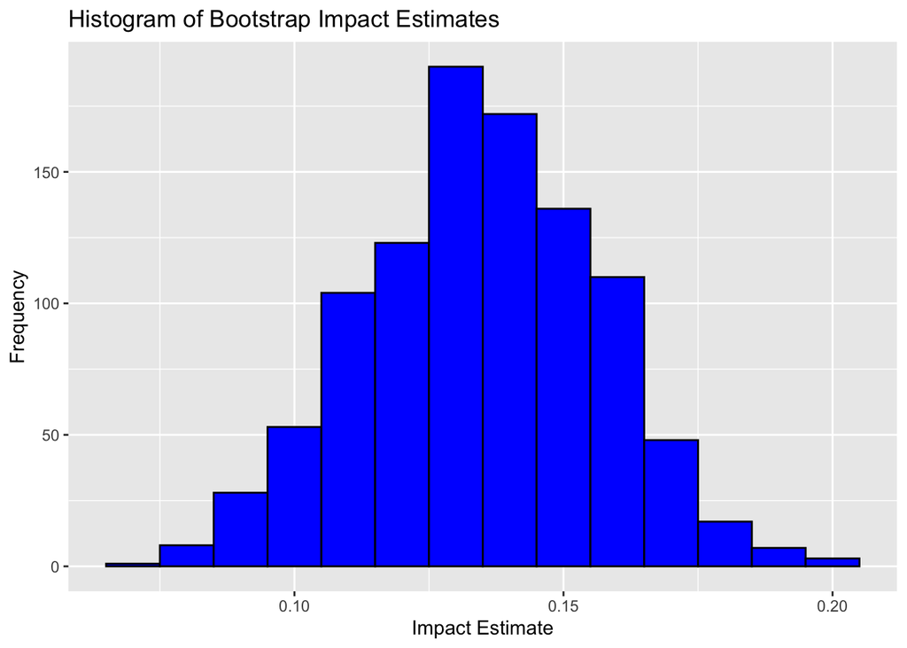

```r
library(ggplot2)

# Convert bs.estimates_forloop to a data frame
bs.estimates_df <- data.frame(impact_estimate = bs.estimates_forloop)

# Create the histogram using ggplot2
ggplot(bs.estimates_df, aes(x = impact_estimate)) +
  geom_histogram(binwidth = 0.01, fill = "blue", color = "black") +
  labs(title = "Histogram of Bootstrap Impact Estimates",
       x = "Impact Estimate",
       y = "Frequency")
```

### Turn this plot into a function so we can use again

```r
plot_boot_histogram <- function(df, col, plot_title) {
# Create the histogram using ggplot2
ggplot(df, aes(x = col)) +
  geom_histogram(binwidth = 0.01, fill = "blue", color = "black") +
  labs(title = plot_title,
       x = "Impact Estimate",
       y = "Frequency")
}
```

### Do same bootstrap using `purrr`

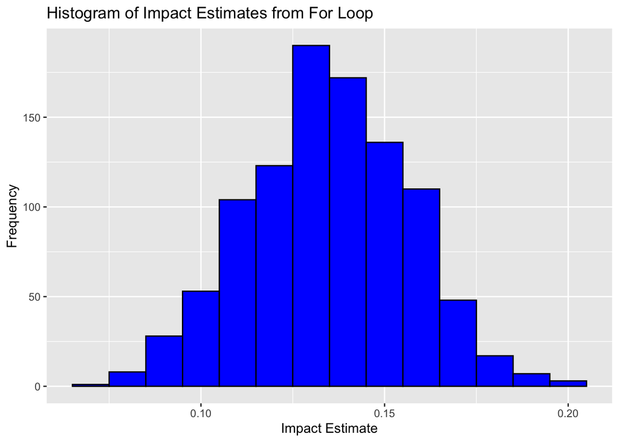

```r
library(purrr)

# Set number of bootstraps
B <- 1000
# Get sample size of data set
samp.size <- nrow(study_data)

# Create a list of bootstrap samples
# Note that in map(), when you use ~, you can write a quick, inline function
bootstrap_samples <- map(1:B, ~ study_data[sample(1:samp.size, replace = TRUE), ])

# Function to estimate impacts with logistic reg + plug-in estimator
bootstrap_iteration <- function(bs.dat) {
  # Fit logistic regression with bootstrap sample
bs.logistic <- glm(smoking_cessation_6months ~ treatment + hospital + nicotine_dependence_imputed + nicotine_dependence_imputed_dummy +  previous_quit_attempts,data=bs.dat)
  # Assign everyone treatment=1 and treatment=0 in bootstrap sample using dplyr
  bs.dat1 <- bs.dat %>% mutate(treatment = 1)
  bs.dat0 <- bs.dat %>% mutate(treatment = 0)
  # Get predictions with treatment=1 and treatment=0
  pred.bs1 <- predict(bs.logistic, newdata = bs.dat1, type = "response")
  pred.bs0 <- predict(bs.logistic, newdata = bs.dat0, type = "response")
  # Get the difference in means to get the bootstrap impact estimate
  mean(pred.bs1) - mean(pred.bs0)
}

# Use map to perform the logistic regression and compute impact estimates
bs.estimates_purrr <- map_dbl(bootstrap_samples, bootstrap_iteration)

# Call function that plots histogram
plot_boot_histogram(bs.estimates_df,bs.estimates_forloop,"Histogram of Impact Estimates from For Loop")
```

## (6) Compute standard error impact estimate

Then, we can compute the standard error by taking the standard deviation of the bootstrapped sampling distribution.

```r
# Find SD of bootstrap sampling distribution
se.impact.estimate <- sd(bs.estimates_purrr)
cat("SE of impact estimate:",se.impact.estimate, "\n")
```

```
## SE of impact estimate: 0.02226201
```

## (7) Create a table of results using gt

```r
library(gt)
 # Create a data frame for the results
  results_df <- data.frame(
    Estimate = c("Treatment Group", "Control Group", "Impact Estimate", "Standard Error"),
    Value = c(mean(predT1), mean(predT0), impact.estimate.plugin, se.impact.estimate)
  )

# Format the results as a gt table
gt_table1 <- gt(results_df) %>%
  tab_header(title = "Estimated treatment effect on smoking cessation at 6 month follow-up") %>%
  fmt_number(columns = c(Value), decimals = 3)

gt_table1
```

Estimated treatment effect on smoking cessation at 6 month follow-up

| Estimate | Value |
| --- | --- |
| Treatment Group | 0.208 |
| Control Group | 0.073 |
| Impact Estimate | 0.135 |
| Standard Error | 0.022 |

Or we could pivot the table:

```r
# Create a data frame for the results
results_df <- data.frame(
  Treatment_Group = mean(predT1),
  Control_Group = mean(predT0),
  Impact_Estimate = impact.estimate.plugin,
  Standard_Error = se.impact.estimate
)

# Format the results as a gt table
gt_table <- gt(results_df) %>%
  tab_header(title = "Estimated treatment effect on smoking cessation at 6 month follow-up") %>%
  fmt_number(columns = everything(), decimals = 3)

# Print the gt table
gt_table
```

Estimated treatment effect on smoking cessation at 6 month follow-up

| Treatment_Group | Control_Group | Impact_Estimate | Standard_Error |
| --- | --- | --- | --- |
| 0.208 | 0.073 | 0.135 | 0.022 |

## (8) Turn entire above procedure into a function so we can repeat for multiple outcomes

```r
# Define the function
estimate_impact <- function(data, outcome, treatment, covariates, plot_title, B = 1000) {
  # Fit the logistic regression model
  formula <- as.formula(paste(outcome, "~", paste(c(covariates, treatment), collapse = " + ")))
  glm_model <- glm(formula, data = data, family = binomial(link = "logit"))

  # Create a data set with treatment = 1 for all observations and get predictions
  data_t1 <- data %>% mutate(!!sym(treatment) := 1)
  pred_t1 <- predict(glm_model, newdata = data_t1, type = "response")

  # Create a data set with treatment = 0 for all observations and get predictions
  data_t0 <- data %>% mutate(!!sym(treatment) := 0)
  pred_t0 <- predict(glm_model, newdata = data_t0, type = "response")

  # Calculate the impact estimate
  impact_estimate <- mean(pred_t1) - mean(pred_t0)

  # Get sample size of data set
  samp_size <- nrow(data)

  # Create a list of bootstrap samples
  bootstrap_samples <- map(1:B, ~ study_data[sample(1:samp.size, replace = TRUE), ])

  # Function to estimate impacts with logistic regression + plug-in estimator
  bootstrap_iteration <- function(bs_data) {
    bs_model <- glm(formula, data = bs_data, family = binomial(link = "logit"))
    bs_data_t1 <- bs_data %>% mutate(!!sym(treatment) := 1)
    bs_data_t0 <- bs_data %>% mutate(!!sym(treatment) := 0)
    pred_bs_t1 <- predict(bs_model, newdata = bs_data_t1, type = "response")
    pred_bs_t0 <- predict(bs_model, newdata = bs_data_t0, type = "response")
    mean(pred_bs_t1) - mean(pred_bs_t0)
  }

  # Use map to perform the logistic regression and compute impact estimates
  bs_estimates <- map_dbl(bootstrap_samples, bootstrap_iteration)

  # Calculate the standard error of the impact estimate
  se_impact_estimate <- sd(bs_estimates)

# Create a data frame for the results
results_df <- data.frame(
  Treatment_Group = mean(pred_t1),
  Control_Group = mean(pred_t0),
  Impact_Estimate = impact_estimate,
  Standard_Error = se_impact_estimate
)

# Format the results as a gt table
gt_table <- gt(results_df) %>%
  tab_header(title = plot_title) %>%
  fmt_number(columns = everything(), decimals = 3)

# Print the gt table
gt_table
}

# Example usage - now we can run same analysis on 1 year follow-up
result_table <- estimate_impact(study_data, "smoking_cessation_1year", "treatment", c("hospital","nicotine_dependence_imputed","nicotine_dependence_imputed_dummy","previous_quit_attempts"),"Estimated treatment effect on smoking cessation at 1 year follow-up")
result_table
```

Estimated treatment effect on smoking cessation at 1 year follow-up

| Treatment_Group | Control_Group | Impact_Estimate | Standard_Error |
| --- | --- | --- | --- |
| 0.074 | 0.081 | −0.006 | 0.017 |

## Modify to run same analysis on multiple outcomes

```r
# Define the function
estimate_impacts <- function(data, outcomes, treatment, covariates, B = 1000) {
  # Helper function to estimate impact for a single outcome
  estimate_single_outcome <- function(outcome) {
    # Fit the logistic regression model
    formula <- as.formula(paste(outcome, "~", paste(c(covariates, treatment), collapse = " + ")))
    glm_model <- glm(formula, data = data, family = binomial(link = "logit"))

    # Create a data set with treatment = 1 for all observations and get predictions
    data_t1 <- data %>% mutate(!!sym(treatment) := 1)
    pred_t1 <- predict(glm_model, newdata = data_t1, type = "response")

    # Create a data set with treatment = 0 for all observations and get predictions
    data_t0 <- data %>% mutate(!!sym(treatment) := 0)
    pred_t0 <- predict(glm_model, newdata = data_t0, type = "response")

    # Calculate the impact estimate
    impact_estimate <- mean(pred_t1) - mean(pred_t0)

    # Get sample size of data set
    samp_size <- nrow(data)

    # Create a list of bootstrap samples
    bootstrap_samples <- map(1:B, ~ study_data[sample(1:samp.size, replace = TRUE), ])

    # Function to estimate impacts with logistic regression + plug-in estimator
    bootstrap_iteration <- function(bs_data) {
      bs_model <- glm(formula, data = bs_data, family = binomial(link = "logit"))
      bs_data_t1 <- bs_data %>% mutate(!!sym(treatment) := 1)
      bs_data_t0 <- bs_data %>% mutate(!!sym(treatment) := 0)
      pred_bs_t1 <- predict(bs_model, newdata = bs_data_t1, type = "response")
      pred_bs_t0 <- predict(bs_model, newdata = bs_data_t0, type = "response")
      mean(pred_bs_t1) - mean(pred_bs_t0)
    }

    # Use map to perform the logistic regression and compute impact estimates
    bs_estimates <- map_dbl(bootstrap_samples, bootstrap_iteration)

    # Calculate the standard error of the impact estimate
    se_impact_estimate <- sd(bs_estimates)

    # Return the results as a list
    list(
      outcome = outcome,
      mean_pred_t1 = mean(pred_t1),
      mean_pred_t0 = mean(pred_t0),
      impact_estimate = impact_estimate,
      se_impact_estimate = se_impact_estimate
    )
  }

  # Apply the estimate_single_outcome function to each outcome
  results_list <- map(outcomes, estimate_single_outcome)

results_df <- bind_rows(results_list) %>%
  select(outcome, mean_pred_t1, mean_pred_t0, impact_estimate, se_impact_estimate) %>%
  rename(
    Outcome = outcome,
    `Treatment` = mean_pred_t1,
    `Control` = mean_pred_t0,
    `Impact Estimate` = impact_estimate,
    `Standard Error` = se_impact_estimate
  )

# Format the results as a gt table
gt_table <- gt(results_df) %>%
  tab_header(title = "Impact Estimate Results for Multiple Outcomes") %>%
  fmt_number(columns = c(`Treatment`, `Control`, `Impact Estimate`, `Standard Error`), decimals = 3)

  gt_table
}

# Example usage:
outcomes_list <- c("smoking_cessation_6months","smoking_cessation_1year")
result_table <- estimate_impacts(study_data, outcomes_list, "treatment", c("hospital","nicotine_dependence_imputed","nicotine_dependence_imputed_dummy","previous_quit_attempts"))
result_table
```

Impact Estimate Results for Multiple Outcomes

| Outcome | Treatment | Control | Impact Estimate | Standard Error |
| --- | --- | --- | --- | --- |
| smoking_cessation_6months | 0.208 | 0.073 | 0.135 | 0.023 |
| smoking_cessation_1year | 0.074 | 0.081 | −0.006 | 0.017 |